# Data Story

Michael Page

05/08/2018

# Perfectionism in the Public Domain: a Natural Language Processing Approach

Michael Page

### 1. INTRODUCTION

##### 1.1 Introduction to the problem

Recent meta-analytical evidence demonstrates that levels of perfectionism in Western populations has linearly increased over the past three decades (Curran & Hill, 2017). This has coincided with a rapid growth in the number of research articles investigating the outcomes, processes, and characteristics associated with perfectionism since the introduction of the first multidimensional perfectionism measures in the early 90’s. Despite a growing body of perfectionism literature in the academic domain, little is known (from the perspective of the academic) regarding reporting standards of perfectionism in the public domain. Indeed, it is important that academic research is *accurately* translated and disseminated to the broader public. Nonetheless, the extent to which this holds true in the realm of perfectionism is unknown.

##### 1.2 Perfectionism

Broadly defined, perfectionism is understood to be a multidimensional personality trait consisting of two higher-order dimensions: perfectionistic strivings and perfectionistic concerns (Stoeber & Otto, 2006). Perfectionistic strivings capture the setting of high performance standards and self- oriented strivings for perfection, whereas perfectionistic concerns capture the negative reactions to imperfections and mistakes, and the fear of negative social appraisal (Gotwals, Stoeber, Dunn, and Stoll, 2012). These two dimensions are considered to be part of a hierarchical model or heuristic representative of a range of different models that exists (Hill, 2016). Multiple reviews support that both perfectionistic strivings and perfectionistic concerns display a typical pattern of findings: perfectionistic strivings are associated with adaptive outcomes, processes and characteristics, whereas perfectionistic concerns are associated with maladaptive outcomes, processes, and characteristics (e.g., Gotwals et al., 2012, Stoeber, 2011, Stoeber & Otto, 2006). One may therefore expect public reporting of perfectionism to reflect this patterns of findings.

##### 1.3 Framing the problem

An assessment of the meaning and social understanding of perfectionism, both in regards to whether it is perceived as a positive and/or negative trait (in line with the research on perfectionistic strivings and perfectionistic concerns), and inferred by the other words/topics it coalesces with, would contribute to research in this area. Fortunately, a wealth of natural language processing tools are at the researchers disposal to answer such questions. These include sentiment analyses and machine learning methods such as topic modelling. The purpose of this project is, therefore, to employ a variety of natural language processing techniques to better understand how perfectionism is reported in the public domain.

### 2. DATA WRANGLING

##### 2.1 NewsRiver API client

To obtain data, an API client for the [NewsRiver API](https://newsriver.io) was built using the ‘httr’ package. Code for the API client (alongside code for the whole project) can be found in the appendix (it should be noted that where relevant, code is also included in text). The NewsRiver API was selected for its large library of news sources and broad range of programmable search parameters. Accordingly, the API client was designed to accept a variety of search parameters from search dates to title and text keyword searches (among others):

```r
# Set date range for api search

search_dates <- seq(as.Date("2017-07-01"), as.Date("2018-07-01"), by = "months")

# Set query parameters to be called

query <- sprintf('title:("perfectionism" OR "perfect") AND text:"perfectionism" AND language:en AND discoverDate:[%s TO %s]', search_dates, search_dates %m+% months(1))
```

##### 2.2 Wrangling JSON files

The API returned a JSON file which was then parsed as text and stored in a data frame object (in this instance as a tibble). The returned tibble contained 19 different variables, many of which contained metadata and non-essential information (e.g., read time, website icon url, etc.). Moreover, many of these non-essential variables contained large quantities of NA values. Subsequently, four key variables of interest (title, text, date, and website) were selected inline with the aims of the project. The website and article publication date variables were renamed, and the article publication date variable was parsed into date format:

```r
# Return error and stop execution if a json is not returned

    if (http_type(resp) != "application/json") {
    stop("API did not return json", call. = FALSE)
    }

    # Return error if there is a http error, else parse the content from the json file and store the title, text, date, and website in a tibble

    if (http_error(resp) == TRUE) {
        warning("The request failed")
    } else {
        news_tbl <- fromJSON(content(resp, as = "text", encoding = "UTF-8"), flatten = TRUE)  %>%
        as_tibble()

        if (nrow(news_tbl) != 0) {
            news_tbl <- news_tbl %>% mutate(date = as.Date(discoverDate), website = website.domainName) %>% select(title, text, date, website)
        }
```

##### 2.3 Cleaning variables

The next step in the data wrangling process involved cleaning the selected variables. The transformed tibble was searched for NA values, of which the website variable was found to contain three. As the website variable was not needed for all analyses, these observations were kept in order to maintain sample size.

After parsing the JSON files, many unicode characters (e.g., “i019m”) were found in the text and title variable data and were transformed into ASCII characters using the ‘stringi’ package:

```r
perf_news %<>% mutate(text = stringi::stri_trans_general(perf_news$text, "latin-ascii"), title = stringi::stri_trans_general(perf_news$title, "latin-ascii"))
```

Next, the tibble was searched for duplicate observations. Strings from the title column were transformed to lower case and then duplicate observations were then removed using the distinct function from ‘dplyr’:

```r
perf_news %<>% mutate(title = str_to_lower(title))
perf_news %<>% distinct(title, .keep_all = TRUE)
```

Finally, the tibble was manually inspected for errors and subsequent observations were removed:

```r
perf_news <- perf_news %>%
  filter(!(perf_news$title == perf_news$title[52])) %>%
  filter(!(perf_news$title == perf_news$title[3]))
```

##### 2.4 Tidy text

For the majority of analyses in this project, a tidy data structure was used. A tidy data structure is one where each variable is a column, each observation is a row, and each type of observational unit is a table (Wickham, 2014). Accordingly, the cleaned tibbles above were tokenised into a ‘tidy text’ format, with one word per row as specified in Silge & Robinson (2017):

```r
tidy_news <- perf_news %>% unnest_tokens(word, text)
```

Finally, stop words (e.g., “the”, “to”, “of”, etc.) were removed:

```r
tidy_news <- tidy_news %>% anti_join(stop_words)
```

### 3. DATA SETS

| title | date | website | word |
| --- | --- | --- | --- |
| perfectionism and poverty: why musicians struggle with mental health | 2018-06-20 | theguardian.com | mental |
| perfectionism and poverty: why musicians struggle with mental health | 2018-06-20 | theguardian.com | illness |
| perfectionism and poverty: why musicians struggle with mental health | 2018-06-20 | theguardian.com | claims |
| perfectionism and poverty: why musicians struggle with mental health | 2018-06-20 | theguardian.com | lives |
| perfectionism and poverty: why musicians struggle with mental health | 2018-06-20 | theguardian.com | music |
| perfectionism and poverty: why musicians struggle with mental health | 2018-06-20 | theguardian.com | helpline |
| perfectionism and poverty: why musicians struggle with mental health | 2018-06-20 | theguardian.com | seeks |
| perfectionism and poverty: why musicians struggle with mental health | 2018-06-20 | theguardian.com | change |
| perfectionism and poverty: why musicians struggle with mental health | 2018-06-20 | theguardian.com | jess |
| perfectionism and poverty: why musicians struggle with mental health | 2018-06-20 | theguardian.com | cornelius |
| perfectionism and poverty: why musicians struggle with mental health | 2018-06-20 | theguardian.com | named |

It should be noted that although the tidy_news data set formed the basic data structure on which an array of analyses were performed, the data set was further wrangled into several other forms. This included a tidy data set tokenised by sentence, and a document-term matrix (among others). In the interest of conciseness, examples of these data sets have been omitted from this report, however, code for these data set transformations can be found in the appendix.

### 4. ANALYSES

##### 4.1 Frequency distributions

In order to understand the underlying structure of the data, several exploratory data analyses were performed.

*Term frequency distribution*: the frequency of terms in each article were calculated and then divided by the total number of terms in each article (i.e., term frequency) as can be seen in Figure 1:

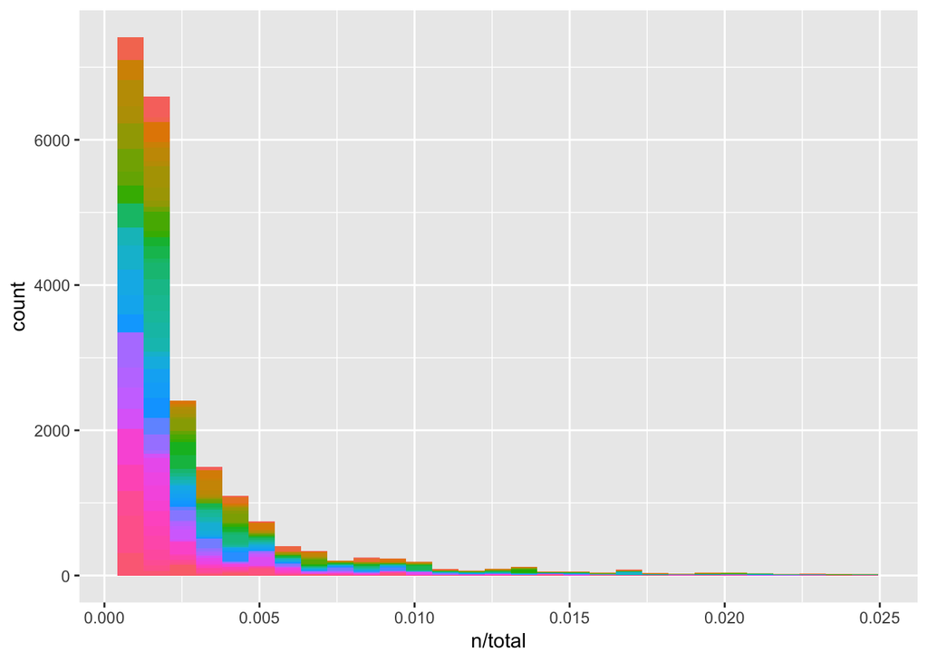

Figure 1. Term frequency across all articles.

The distribution in Figure 1 demonstrates a large positive skew, as would be expected in a corpus of natural language such as the one in this study. This is because some types of words such as articles (e.g., ‘the’) appear more frequently than other types of words.

*Zipf’s law*: to further explore the term frequency distribution in Figure 1, frequency rank against term frequency (on logarithmic scales) was plotted. A linear model was fitted to the plot to further examine the underlying data structure (Figure 2):

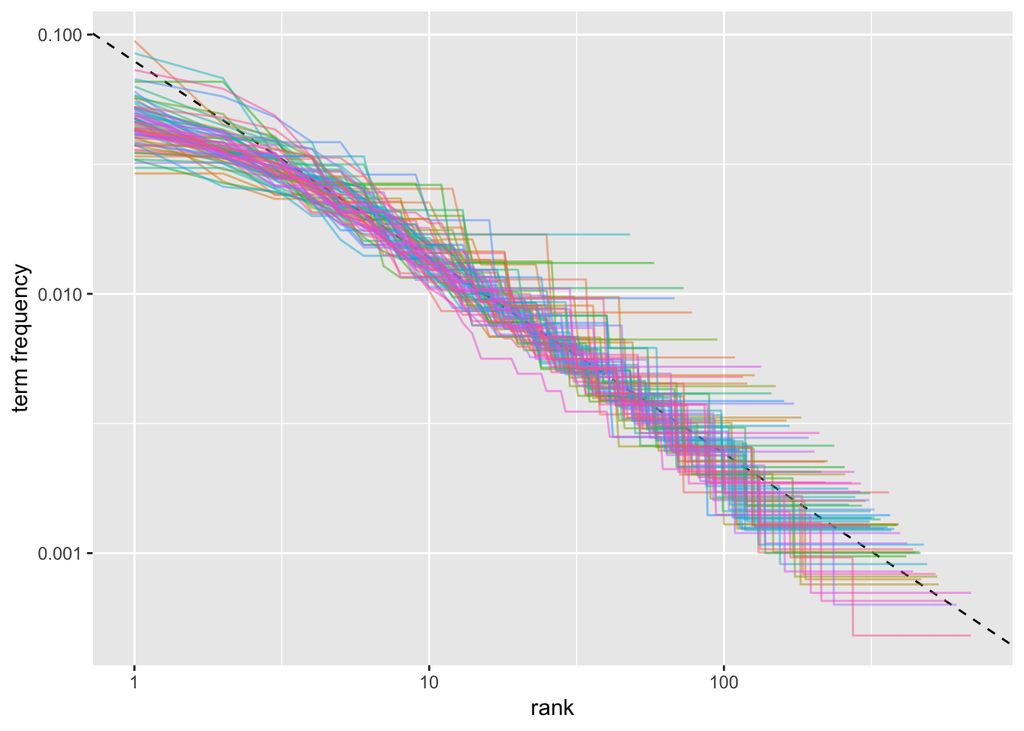

Figure 2. Zipfs law applied to the data.

The relationship between term frequency and rank in Figure 2 represents that of Zipf’s law (an interpretation of the power law). That is, that there is an inverse relationship between term frequency and rank (i.e., the most frequent word will occur approximately twice as often as the second most frequent word, etc.). The middle section of the rank range in Figure 2 has a gradient of -0.76, as determined by the fitted linear model, demonstrating that the data in this study does not strictly abide to Zipf’s law (i.e., a perfect case of Zipf’s law would result in a gradient of -1). Furthermore, there are small deviations at both the higher and lower ranked words. This means that the data set contains fewer rare and common words than would typically be predicted by a power law. Nonetheless, these kind of deviations are not uncommon for many kinds of natural language (Silge & Robinson (2017). Collectively, the plots in Figure 1 and Figure 2 confirm that data in this project represent a typical corpus of natural language, justifying further analyses.

##### 4.2 Word frequencies

To understand the basic text composition of the corpus of news articles, a list of custom stop words was removed from the data (see appendix) and the most common words were found (Figure 3):

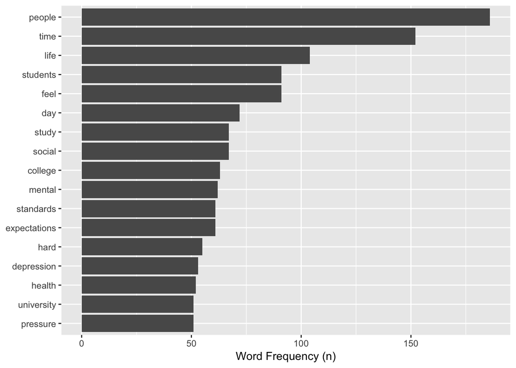

Figure 3. The most common words across all articles.

The most common words match those one would expect to find in a corpus of language discussing perfectionism. For example, words such as ‘expectations’, ‘standards’, and ‘pressure’ appear, words commonly used in the academic domain that reflect the high expectations perfectionists place upon themselves. Other words such as ‘students’, ‘college’, and ‘university’ also appear, again, unsurprising given that large body of academic research has been conducted in University samples. This basic frequency analysis indicates that the words used in this corpus of text can be paralleled to that in the academic domain. Figure 4 demonstrates a further exploration into the most common words used (with the size of the word equating to frequency):

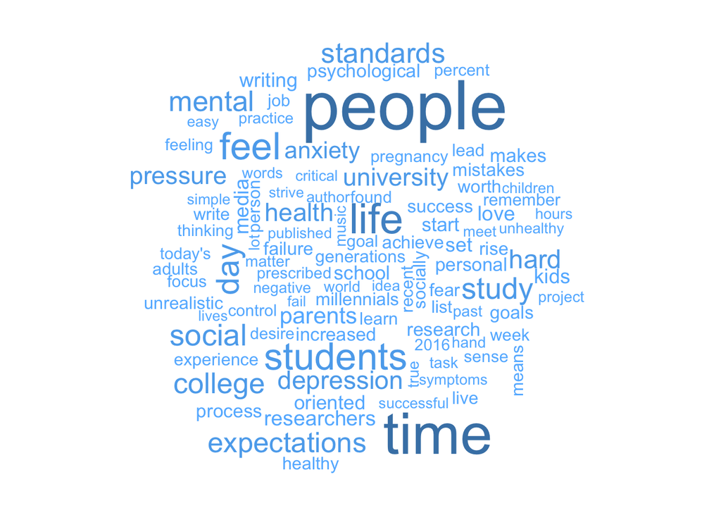

Figure 4. A word cloud of the most frequent perfectionism terms used across all articles.

##### 4.3 Sentiment Analyses

*Sentiment time analysis*: Having established that the data represented a typical corpus of natural language, and contained words inline with those one may expect in a corpus of text examining perfectionism, a sentiment analysis over time was performed. This was done in order to explore the underlying polarity of the data (i.e., is perfectionism reported in a positive or negative fashion), and to see if this has changed over time. To achieve this, articles were first tokenised by sentence and assigned a sentence number. Next, the sentences were tokenised by word. To compute a sentiment score for each article, individual word sentiment scores across each sentence were summed, and then each sentence sentiment score across each article was summed. Analyzing sentiment in sentence units, as was done here, better captures the structure of natural language over simpler unigram methods such as summing individual word sentiment scores across a whole text (Silge & Robinson, 2017). In order to provide a multifaceted sentiment analysis, three sentiment lexicons (AFINN, Bing, and NRC) were used to determine the sentiment of each article. For each lexicon, sentiment was split into negative and positive classifications, inline with the theory on perfectionistic strivings and perfectionistic concerns, as can be seen in Figure 5:

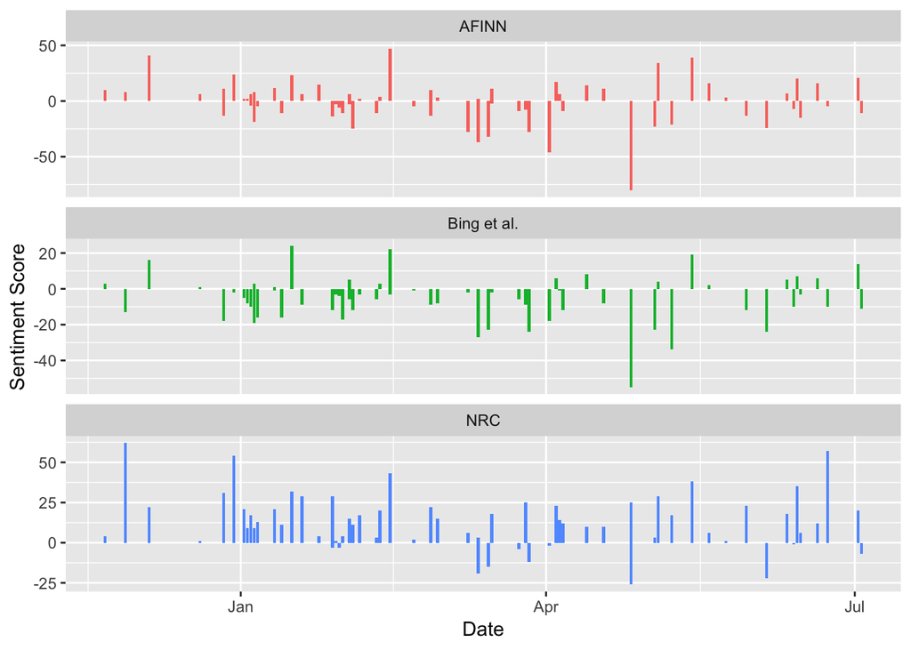

Figure 5. Sentiment analysis over time.

| sentiment | n | lexicon |
| --- | --- | --- |
| negative | 3324 | nrc |
| positive | 2312 | nrc |
| negative | 4782 | bing |
| positive | 2006 | bing |

*Frequent positive and negative words*: the most frequent positive and negative words across all texts were found using the Bing sentiment lexicon as shown in Figure 6:

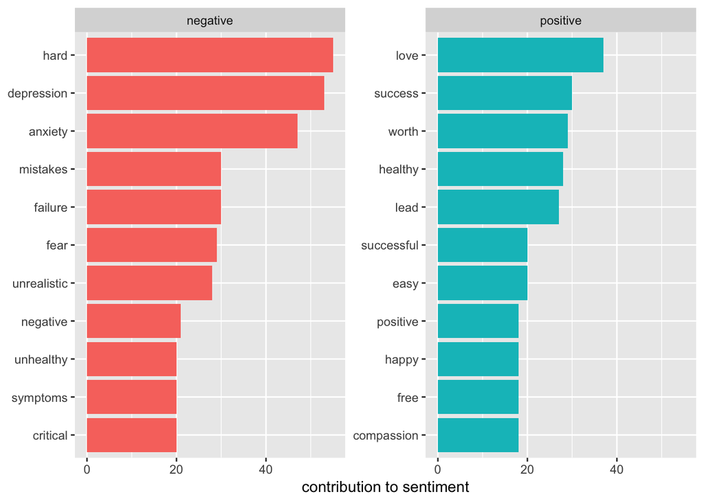

Figure 6. The most frequent positive and negative terms contributing to sentiment.

Similar to the term frequency analysis conducted earlier, many predictable terms appear. For example, of the most frequent negative terms, ‘failure’, ‘mistakes’, and ‘unrealistic’ are commonly used in the academic literature to denote the unrealistic expectations perfectionists demand upon themselves, and their associated fear of failure and mistakes. This also extends to terms such as ‘hard’, ‘unhealthy’, and ‘depression’, terms in the academic literature which denote the experiences perfectionists typically find themselves in. On the contrary, of the most frequent positive terms, many terms appear unexpected. Indeed some terms such as ‘positive’ and ‘healthy’ do parallel those terms used in the academic literature (denoting perfectionistic strivings), however, terms such as ‘love’, ‘worth’, and ‘happy’ are not common occurrences in academic texts. Moreover, one would expect literature discussing perfectionism to discuss low self-worth, and a deficit of happiness and love reflecting the relationship and life difficulties associated with perfectionism (Dunkley et al., 2003; Hewitt and Flett, 2002). Perhaps one explanation for the occurrence of unexpected words is the use of unigrams to determine sentiment. Indeed, statements such as ‘not happy’ reflect a negative sentiment, yet result in a positive sentiment as the outcome (i.e, not gets discarded as a stop word and happy gets treated as a positive sentiment). One way to overcome and further explore this is through the use of bigrams.

##### 4.4 Bigrams

*Bigram sentiment time analysis*: in order to account for any negation words in the data set and their effect on sentiment scores, a further sentiment analysis using bigrams was performed. First, the perf_news data set was tokenised by bigrams while keeping track of sentence number. Then, a sentiment analysis was performed by reversing the sentiment score of any bigrams that matched a list of negation words (‘not’, ‘never’, ‘no’, ‘without’). As was done in the unigram sentiment analysis conducted previously, individual word sentiment scores across each sentence were summed, and then each sentence sentiment score across each article was summed to achieve a sentiment score for each article, as can be seen in Figure 7:

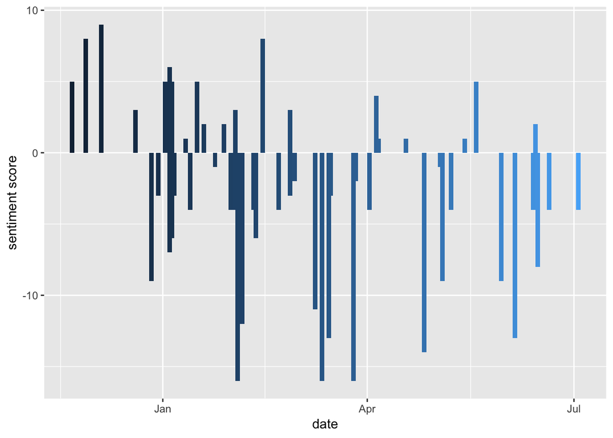

Figure 7. Sentiment analysis over time using bigrams.

The data in Figure 7 demonstrate that after controlling for negation words, the articles still maintained a split across both positive and negative sentiments. However, in this instance, there was a heavier weighting towards a negative sentiment.

*Bigram frequency*: having tokenised the data set by bigrams, a frequency count of the most common bigrams was computed to further explore the underlying structure of the data, as can be seen in the table below:

| word1 | word2 | n |
| --- | --- | --- |
| college | students | 45 |
| mental | health | 32 |
| social | media | 29 |
| socially | prescribed | 20 |
| psychological | bulletin | 18 |
| thomas | curran | 17 |
| depressive | symptoms | 14 |
| john | university | 14 |
| st | john | 14 |
| york | st | 14 |

The data in the above table demonstrates that the public reporting of perfectionism is inline with the latest research in the academic domain. For instance, the most frequent bigram terms closely match those of a recent publication by Curran and Hill (2017) published in Psychological Bulletin in which ‘social media’, ‘socially prescribed (perfectionism)’ and ‘mental health’ are discussed in the context of college students

*Bigram igraph*: to visualise the relationship among bigrams simultaneously, the data was arranged into a network of connected nodes, as can be seen in Figure 8:

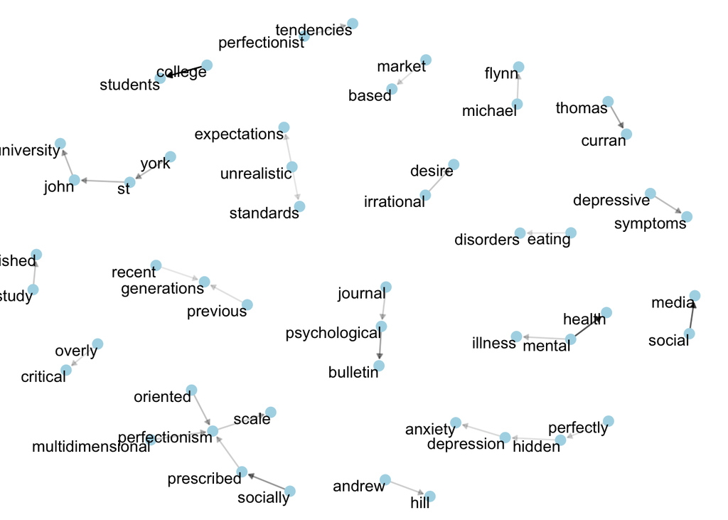

Figure 8. The most frequent bigrams visualised as a network of connected nodes.

##### 4.5 Pairwise correlations

*Pairwise correlations*: to determine which words various perfectionism terms (e.g., perfect, perfectionist, etc.) coalesce with, pairwise correlations were calculated using the phi coefficient. This identified how much more likely it was that a word would appear in conjunction with a perfectionism term, or that neither term appeared, than that one appeared without the other (Figure 9):

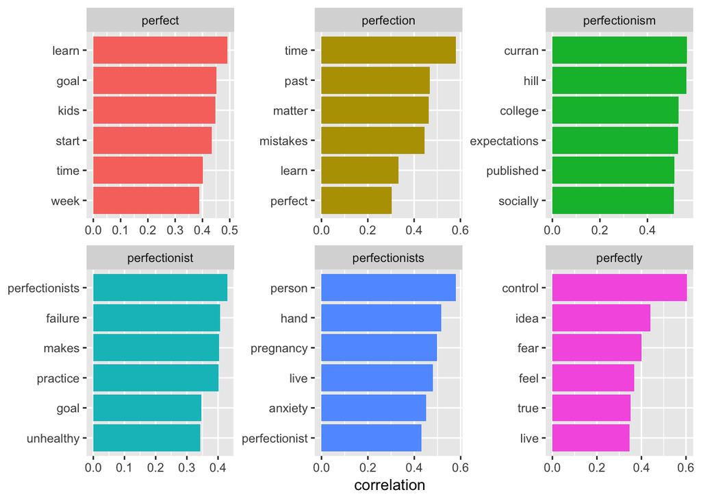

Figure 9. Pairwise correlations with various perfectionism terms.

With the exception of the terms ‘perfect’ and ‘perfectionists’, the words correlated with the other perfectionism terms mirrors that of those found in the frequency analysis conducted previously. These words include mistakes, fear, failure, and ‘expectations’, all words in the arsenal of the academic perfectionism lexicon. The terms correlated with ‘perfect’ and ‘perfectionists’ on the other hand are not in keeping with this theme. For instance, the occurrence of the terms ‘pregnancy’, ‘person’, ‘kids’, and ‘week’ do not have any discernible significance in the academic perfectionism literature. A quick exploration of the perf_news data set reveals that three articles discuss perfectionism and pregnancy, with one article (‘perfectionism and the pregnant woman’) containing both terms in the title, explaining the correlation these terms.

### 5. NEXT STEPS

Having explored the data and highlighted that the text represents a natural corpus of language that closely mirrors that of research in the academic domain, the next step is to explore the underlying topics in the data. This is important because it will provide further information on the topics perfectionism coalesces with in the public domain. To achieve this, the data will be transformed into a document-term matrix and topic models will be fitted to the data using the ‘topicmodels’ package, and optimised using the ‘ldatuninig’ package.